# Localize Campaign Analysis

This is an analysis of Localize Marketing Campaigns, per the overview provided in the pdf instructions provided [here](https://github.com/gottalottasoul/localize_hw/blob/main/Localize%20-%20Home%20Assignment%2C%20Senior%20BA%20Analyst.pdf). The full source code for this analysis can be found on github as well, in [this repository](https://github.com/gottalottasoul/localize_hw). Please feel free to reach out to me with any questions as needed.

## Caveat Emptor

Before providing my analysis of the provided data, I would first call attention to what data is *not* provided. In a real world scenario, I would be hesitant to provide any analysis that’s primary metric was focused on visits/sessions, particularly as it relates to paid channels.

A few questions or additional pieces of data I would consider asking for to provide a fuller analysis would be:

1. Campaign Name
2. Raw Spend data per date per source/campaign
3. Additional traffic data from non-paid sources
4. An additional Key goal metric to accompany visit (conversion, lead submission, etc.)

## Data Overview

Data summary

| Name | localize_user_sessions |
| --- | --- |
| Number of rows | 2320 |
| Number of columns | 3 |
| _______________________ |  |
| Column type frequency: |  |
| character | 1 |
| logical | 1 |
| POSIXct | 1 |
| ________________________ |  |
| Group variables | None |

**Variable type: character**

| skim_variable | n_missing | complete_rate | min | max | empty | n_unique | whitespace |
| --- | --- | --- | --- | --- | --- | --- | --- |
| user_id | 0 | 1 | 8 | 12 | 0 | 908 | 0 |

**Variable type: logical**

| skim_variable | n_missing | complete_rate | mean | count |
| --- | --- | --- | --- | --- |
| is_session | 0 | 1 | 1 | TRU: 2320 |

**Variable type: POSIXct**

| skim_variable | n_missing | complete_rate | min | max | median | n_unique |
| --- | --- | --- | --- | --- | --- | --- |
| date | 0 | 1 | 2020-11-02 | 2020-12-27 | 2020-12-02 | 55 |

### EDA

A few quick charts to get a sense of the shape and magnitude of the data.

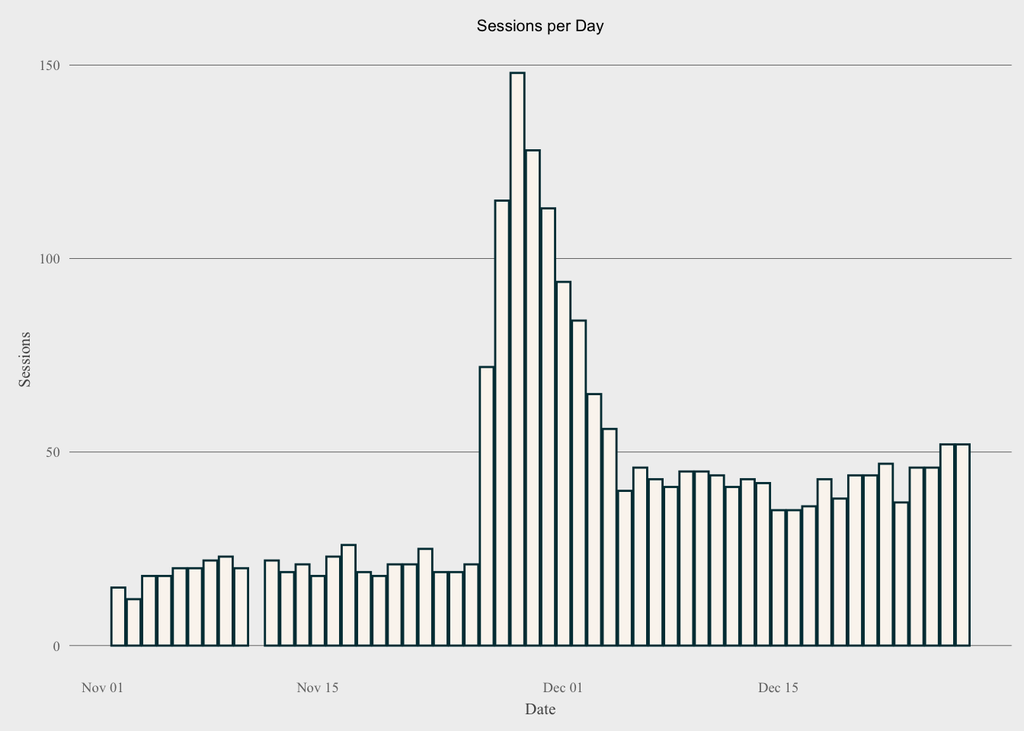

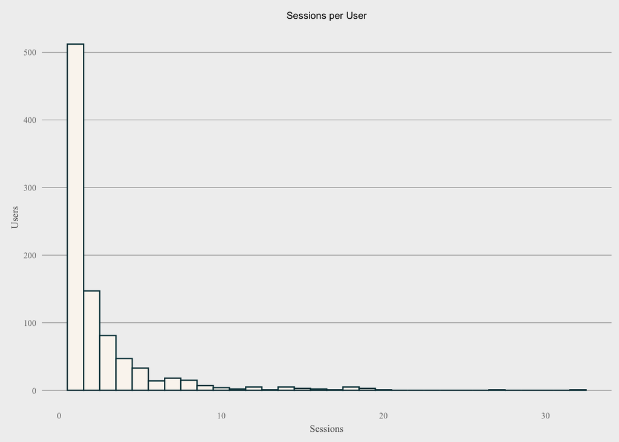

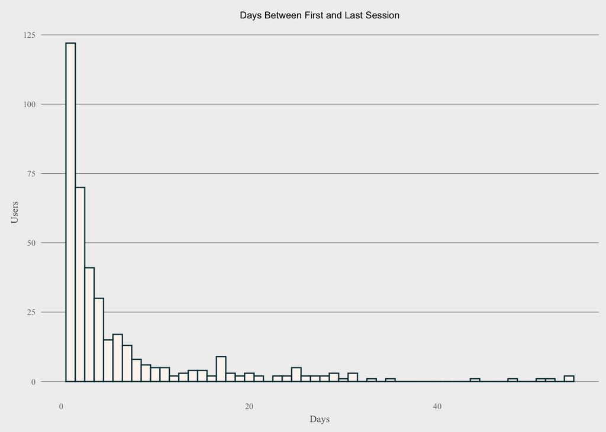

Let’s take a closer look at the distribution of sessions per day

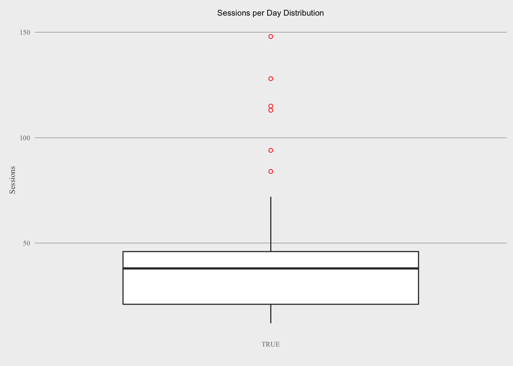

It is interesting to see the peaks in late November/early December technically classified as outliers using standard definitions (*1.5x upper/lower quantile ranges*). Given the limited amount of data (as well as relatively small ranges), I would not make anything of this yet but would revisit it as we continue to enrich our dataset.

### Data Cleansing

Now that we’ve examined the primary dataset, a quick overview of the ancillary data sources:

Data summary

| Name | localize_user_sources |
| --- | --- |
| Number of rows | 907 |
| Number of columns | 2 |
| _______________________ |  |
| Column type frequency: |  |
| character | 2 |
| ________________________ |  |
| Group variables | None |

**Variable type: character**

| skim_variable | n_missing | complete_rate | min | max | empty | n_unique | whitespace |
| --- | --- | --- | --- | --- | --- | --- | --- |
| user_id | 0 | 1 | 8 | 8 | 0 | 907 | 0 |
| campaign_source | 0 | 1 | 4 | 8 | 0 | 4 | 0 |

| campaign_source | users | occurrences |
| --- | --- | --- |
| fb_1 | 319 | 319 |
| fb_2 | 26 | 26 |
| google_1 | 408 | 408 |
| insta_1 | 154 | 154 |

| campaign | ppu |
| --- | --- |
| fb_1 | 1.1 |
| fb_2 | 1.5 |
| google_adwords | 1.1 |
| instagram_thx | 3.5 |

A cursory overview of the campaign costs and user_sources data shows a mismatch of a few campaign names. For the purposes of this exercise, I will assume the instagram and google campaigns are intended to be referencing the same campaigns. I’m going to add a new column to our campaign costs dataset to account for the name differences.

Now we can join our 3 datasets so we have source names and average click costs sitting along side individual sessions:

| campaign | users | sessions | sess_per_user |
| --- | --- | --- | --- |
| fb_1 | 319 | 375 | 1.175549 |
| fb_2 | 26 | 91 | 3.500000 |
| google_adwords | 406 | 859 | 2.115764 |
| instagram_thx | 154 | 940 | 6.103896 |
| NA | 3 | 55 | 18.333333 |

We can see there are a small subset of users who are not associated with a campaign, and have an abnormally high average of Sessions Per User

| user_id |
| --- |
| a9CYYJHc_tst |
| K2XwtYd5_tst |
| ZGpUHYz9_tst |

These 3 user_ids are appended with a ’_tst’ suffix. I will assume this is a designation of test users and will exclude them from our final dataset. Now that we have a scrubbed full dataset, it’s ready for analysis.

## Analysis

To start, let’s take a look at sessions by campaign by day.

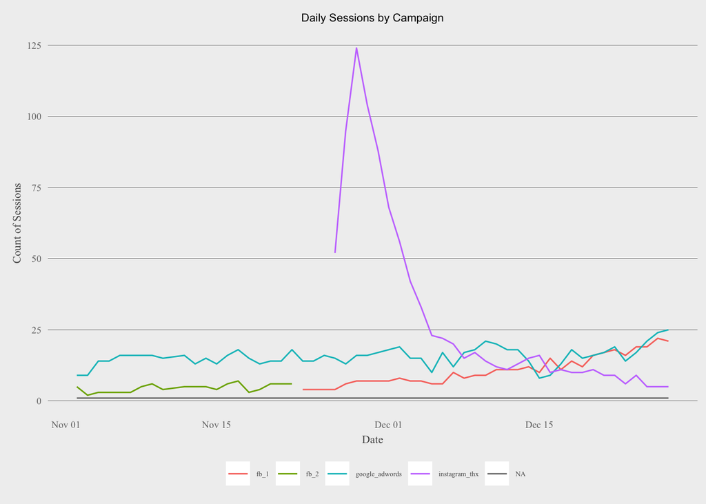

From this view, a couple of things stand out. First, it would appear that the 2 Facebook campaigns are not independent of one another; but rather one is a continuation of the other. It warrants further investigation to understand the cost discrepancy between the two (if one is, in fact, a relaunch of the original). Even more conspicuous is the ‘performance’ of the instagram campaign. Given the limitations of our dataset, its hard to place the performance of Instagram in context. It could be a big ad buy, or juicing an already viral post with boosting, that is driving the one day spike.

What is undeniable, however, is that instagram users are ‘stickier’ than other channels. As seen in the following chart and table, sessions per unique user for Instagram far exceed our other two ad platforms.

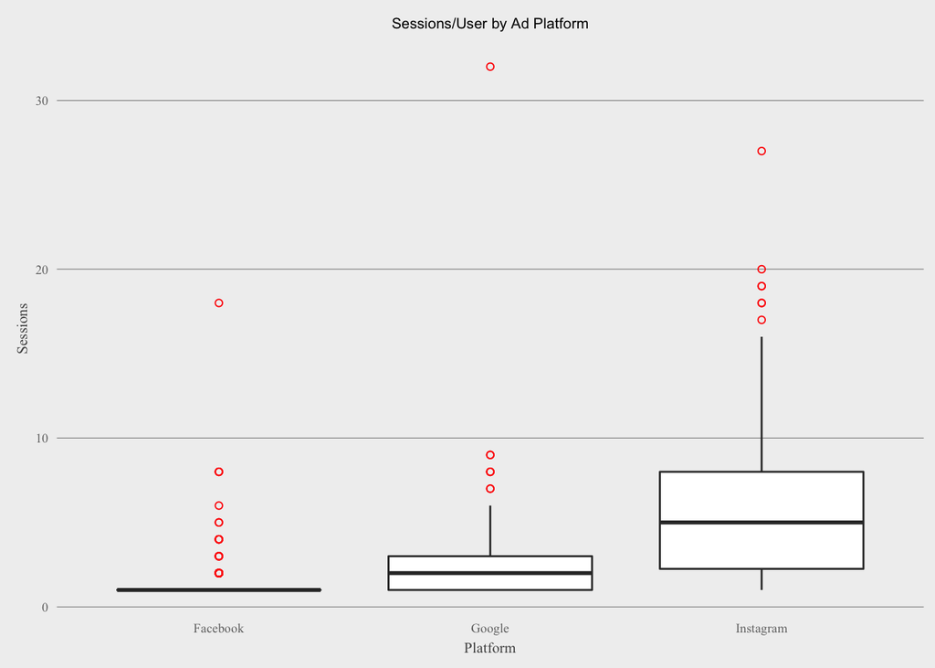

| campaign | users | sessions | spend | sessions_per_user |
| --- | --- | --- | --- | --- |
| fb_1 | 319 | 375 | 412.5 | 1.175549 |
| fb_2 | 26 | 91 | 136.5 | 3.500000 |
| google_adwords | 406 | 859 | 944.9 | 2.115764 |
| instagram_thx | 154 | 940 | 3290.0 | 6.103896 |
| NA | 3 | 55 | NA | 18.333333 |

*To this point, i have been assuming ppu is ‘Price Per (Ad) Unit’. If we tweak this and assume ppu is in fact Price Per User, so that it is a normalized cost across user_id, we can then calculate a cost per session.*

In lieu of another datapoint to identify a conversion, we will use repeat users as a proxy for value and count returning visitors as our ‘conversion ’metric’ for this portion.

| campaign | users | sessions | spend | converters | conversion_rate | sessions_per_user | cost_per_sess | cost_per_converter |
| --- | --- | --- | --- | --- | --- | --- | --- | --- |
| fb_1 | 319 | 375 | $350.90 | 37 | 12% | 1.175549 | $0.94 | $9.48 |
| fb_2 | 26 | 91 | $39 | 22 | 85% | 3.500000 | $0.43 | $1.77 |
| google_adwords | 406 | 859 | $446.60 | 205 | 50% | 2.115764 | $0.52 | $2.18 |
| instagram_thx | 154 | 940 | $539 | 129 | 84% | 6.103896 | $0.57 | $4.18 |

```
Pearson's Chi-squared test with Yates' continuity correction
```

data: M X-squared = 0.00019459, df = 1, p-value = 0.9889

## Recommendations

Given the above, I would make the following recommendations: